# 06

```python
import pandas as pd
```

### Portfolio assignment 6

60 min: Perform a univariate analysis on at least 2 columns with categorical data and on at least 2 columns with numerical data in the dataset that you chose in portfolio assignment 4. Commit the Notebook to your portfolio when you're finished.

```python
hostels = pd.read_csv('../data/hostel.csv')
```

```python
hostels.head()
```

|  | Unnamed: 0 | hostel.name | City | price.from | Distance | summary.score | rating.band | atmosphere | cleanliness | facilities | location.y | security | staff | valueformoney | lon | lat |
| --- | --- | --- | --- | --- | --- | --- | --- | --- | --- | --- | --- | --- | --- | --- | --- | --- |
| 0 | 1 | "Bike & Bed" CharinCo Hostel | Osaka | 3300 | 2.9km from city centre | 9.2 | Superb | 8.9 | 9.4 | 9.3 | 8.9 | 9.0 | 9.4 | 9.4 | 135.513767 | 34.682678 |
| 1 | 2 | & And Hostel | Fukuoka-City | 2600 | 0.7km from city centre | 9.5 | Superb | 9.4 | 9.7 | 9.5 | 9.7 | 9.2 | 9.7 | 9.5 | NaN | NaN |
| 2 | 3 | &And Hostel Akihabara | Tokyo | 3600 | 7.8km from city centre | 8.7 | Fabulous | 8.0 | 7.0 | 9.0 | 8.0 | 10.0 | 10.0 | 9.0 | 139.777472 | 35.697447 |
| 3 | 4 | &And Hostel Ueno | Tokyo | 2600 | 8.7km from city centre | 7.4 | Very Good | 8.0 | 7.5 | 7.5 | 7.5 | 7.0 | 8.0 | 6.5 | 139.783667 | 35.712716 |
| 4 | 5 | &And Hostel-Asakusa North- | Tokyo | 1500 | 10.5km from city centre | 9.4 | Superb | 9.5 | 9.5 | 9.0 | 9.0 | 9.5 | 10.0 | 9.5 | 139.798371 | 35.727898 |

The capital seems to have the most hostels available.

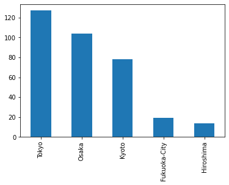

```python
hostels['City'].value_counts().plot(kind='bar')
```

We're not talking about Euros here, but Yen.

These prices are in Yen, this seems cheap at first if you convert the values to Euro, but the data set is from 2017

[figure not shown]

When looking at the current exchange rate it's higher than right now, meaning if you converted from Yen to Euros the value would be lower.  
So if we went from Yen To Euro we'd have to add another 5% to the Yen we have first to get an accurate daily price.  
For example 3300x1.05 = 3465, which would right now (Feb 2022) 27.48 EUR.  
This may seem low, but we're talking about hostels not hotels.  
Blogpost about Japanese hostels: https://www.japan-guide.com/e/e2030.html

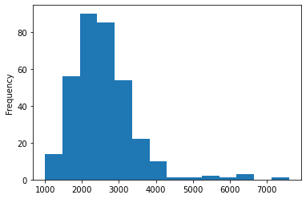

```python
high_price_filter = hostels['price.from'] < 10**5
hostels['price.from'][high_price_filter].plot(kind='hist', bins=14)
```

### outliers

There are 2 hotels above a normal price, which we've filtered out to get a proper looking hist chart. The outrlier will be listed seperately below:

```python
hostels[high_price_filter == False]
```

|  | Unnamed: 0 | hostel.name | City | price.from | Distance | summary.score | rating.band | atmosphere | cleanliness | facilities | location.y | security | staff | valueformoney | lon | lat |
| --- | --- | --- | --- | --- | --- | --- | --- | --- | --- | --- | --- | --- | --- | --- | --- | --- |
| 289 | 290 | Shell Nell namba | Osaka | 1003200 | 4.8km from city centre | 8.3 | Fabulous | 6.0 | 8.0 | 9.0 | 9.0 | 9.0 | 9.0 | 8.0 | 135.506291 | 34.663375 |
| 316 | 317 | Tokyo Central Youth Hostel | Tokyo | 1003200 | 4.8km from city centre | 8.0 | Fabulous | 6.0 | 10.0 | 10.0 | 8.0 | 8.0 | 8.0 | 6.0 | 139.743522 | 35.700821 |

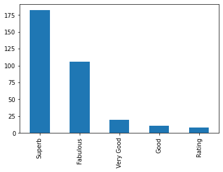

```python
hostels['rating.band'].value_counts().plot(kind='bar')
```

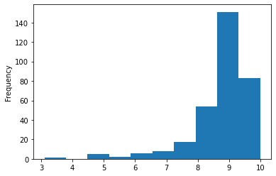

```python
hostels['summary.score'].plot(kind='hist')
```

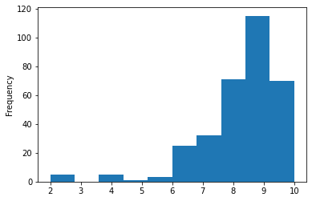

```python
hostels['atmosphere'].plot(kind='hist')
```

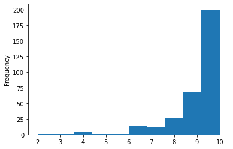

```python
hostels['cleanliness'].plot(kind='hist')
```

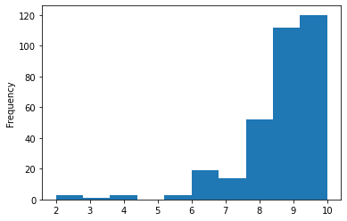

```python
hostels['facilities'].plot(kind='hist')
```

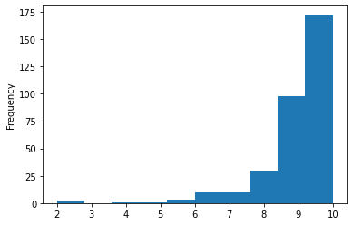

```python
hostels['security'].plot(kind='hist')
```

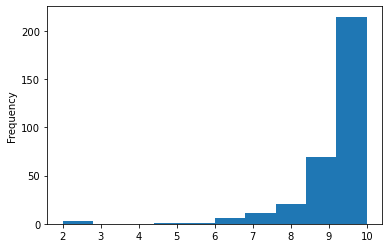

```python
hostels['staff'].plot(kind='hist')
```

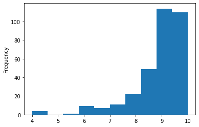

```python
hostels['valueformoney'].plot(kind='hist')
```

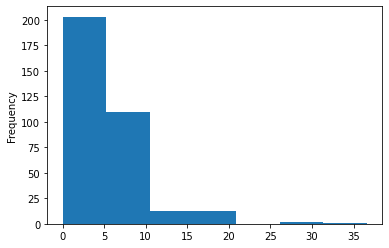

```python
hostels["Distance_in_KM"] = hostels["Distance"].astype('str').str.extractall('(\d+)').unstack().fillna('').sum(axis=1).astype(int)
hostels["Distance_in_KM"] = hostels["Distance_in_KM"].div(10)
hostels["Distance_in_KM"].plot(kind="hist", bins=7)
```